# p5

## Convolutional Neural Network

### Brain Tumor Classification

```python
import numpy as np
import pandas as pd
import matplotlib.pyplot as plt
import torch
import torch.nn as nn
import torch.nn.functional as F
import torch.optim as optim
from torch.utils.data import Dataset
from torch.utils.data import DataLoader
import PIL
import glob
import os
import matplotlib.image as mpimg
from sklearn.model_selection import train_test_split
from torchvision import transforms
import cv2
from sklearn import metrics
from sklearn.metrics import classification_report
```

```python
!unzip AI-CA5-Dataset
```

[output not shown]

[output cut: 1262 more lines]

[output not shown]

#### Define classes

First I create dataset class that inherits from Dataset in pytorch

```python
class Image_Dataset (Dataset):
  def __init__ (self, addrs, labels, transform):
    super ().__init__ ()
    self.transform = transform
    self.classes_addrs = addrs
    self.classes_labels = labels

  def __getitem__ (self, idx):
    image_addr = self.classes_addrs[idx]
    label = self.classes_labels[idx]

    img = np.array (cv2.imread(image_addr, cv2.IMREAD_GRAYSCALE))

    img = self.transform (img)

    label = np.array (label)

    return img, torch.tensor (label)

  def __len__ (self):
    return len (self.classes_addrs)
```

I create Model class that inherits from nn.Module in pytorch. </br> In my model, first I created a convolutional layer that is used for feature extraction after that I used ReLU for activation function and after that I used maxpool layer that reduce the size of the image with finding the maximum value in a 2*2 part of the image it has some benefits like feature robustness, computationally efficient, reduction of overfitting and memory efficiency. I repeated these layers three times, so the depth of my model is three. After that there is a flatten layer between feature extraction and classification After feature extraction I used linear layer for classification. I used three linear layer and between linear layers I used dropout layers that are good for improving training stability. The output layer has four neurons because we have four classes.

```python
class Model (nn.Module):
    def __init__(self):
        super().__init__()
        self.conv1 = nn.Conv2d(1, 16, 3, padding = "same")
        self.b1 = nn.BatchNorm2d (16)
        self.pool = nn.MaxPool2d(2, 2)
        self.conv2 = nn.Conv2d(16, 32, 3, padding = "same")
        self.b2 = nn.BatchNorm2d (32)
        self.pool = nn.MaxPool2d(2, 2)
        self.conv3 = nn.Conv2d(32, 64, 3, padding = "same")
        self.b3 = nn.BatchNorm2d (64)
        self.pool = nn.MaxPool2d(2, 2)
        self.fc1 = nn.Linear(64 * 64 * 64, 1024)
        self.d1 = nn.Dropout (p = 0.2)
        self.fc2 = nn.Linear(1024, 256)
        self.d2 = nn.Dropout (p = 0.2)
        self.fc3 = nn.Linear(256, 4)

    def forward(self, x):
        x = self.conv1 (x)
        x = F.relu (x)
        x = self.b1 (x)
        x = self.pool(x)
        x = self.conv2 (x)
        x = F.relu (x)
        x = self.b2 (x)
        x = self.pool (x)
        x = self.conv3 (x)
        x = F.relu (x)
        x = self.b3 (x)
        x = self.pool (x)
        x = torch.flatten(x, 1)
        x = self.fc1 (x)
        x = F.relu (x)
        x = self.d1 (x)
        x = self.fc2 (x)
        x = F.relu (x)
        x = self.d2 (x)
        x = self.fc3(x)
        return x
```

#### Reading data

For reading data I interate dataset and store their addresses and labels and after that split data to train and test with ratio 0.8 for train.

```python
dir = "AI-CA5-Dataset"

classes = os.listdir (dir)
classes_num = [0, 1, 2, 3]

class1_addrs = glob.glob (dir + "/" + classes[0] + "/*")
class2_addrs = glob.glob (dir + "/" + classes[1] + "/*")
class3_addrs = glob.glob (dir + "/" + classes[2] + "/*")
class4_addrs = glob.glob (dir + "/" + classes[3] + "/*")

class1_labels = [classes_num[0] for i in range (len (class1_addrs))]
class2_labels = [classes_num[1] for i in range (len (class2_addrs))]
class3_labels = [classes_num[2] for i in range (len (class3_addrs))]
class4_labels = [classes_num[3] for i in range (len (class4_addrs))]

classes_addrs = class1_addrs + class2_addrs + class3_addrs + class4_addrs
classes_labels = class1_labels + class2_labels + class3_labels + class4_labels

train_classes_addrs, test_classes_addrs, train_classes_labels, test_classes_labels = train_test_split (classes_addrs, classes_labels, train_size = 0.8, stratify = classes_labels)
```

Now, I plot number of classes for train set and data set. Notumor class has more sample than others. It can cause model to has bias. We can use some methods like fliping image to create new images for other classes.

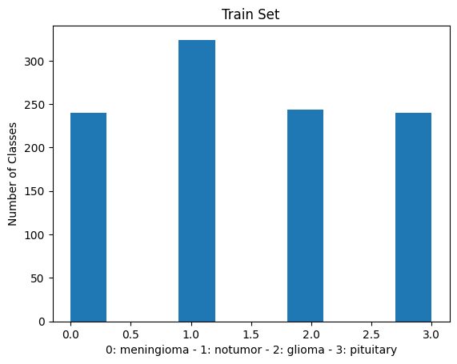

```python
plt.hist (train_classes_labels)
plt.title ("Train Set")
plt.xlabel ("0: meningioma - 1: notumor - 2: glioma - 3: pituitary")
plt.ylabel ("Number of Classes")
plt.show ()
```

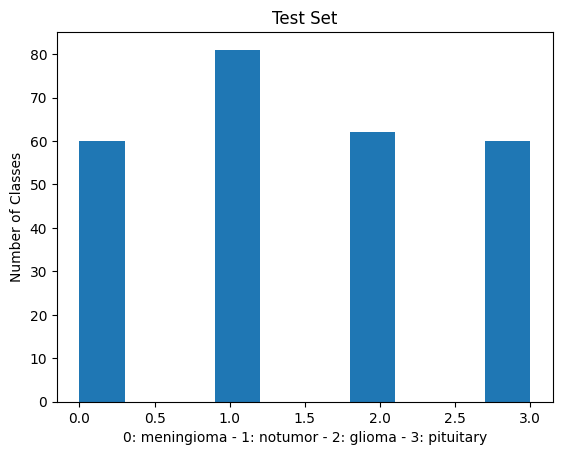

```python
plt.hist (test_classes_labels)
plt.title ("Test Set")
plt.xlabel ("0: meningioma - 1: notumor - 2: glioma - 3: pituitary")
plt.ylabel ("Number of Classes")
plt.show ()
```

Here, I show a sample of each class.

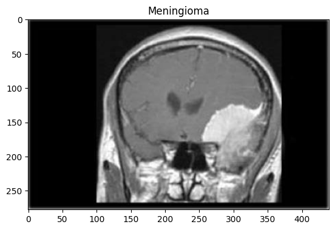

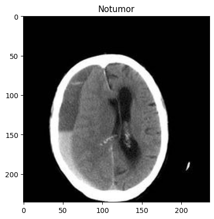

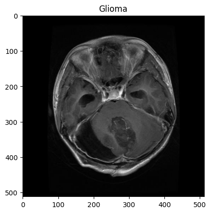

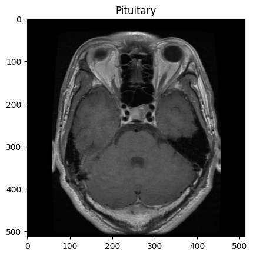

```python
image = mpimg.imread("AI-CA5-Dataset/meningioma/Te-meTr_0000.jpg")
plt.title ("Meningioma")
plt.imshow(image)
plt.show()

image = mpimg.imread("AI-CA5-Dataset/notumor/Te-noTr_0000.jpg")
plt.title ("Notumor")
plt.imshow(image)
plt.show()

image = mpimg.imread("AI-CA5-Dataset/glioma/Te-glTr_0000.jpg")
plt.title ("Glioma")
plt.imshow(image)
plt.show()

image = mpimg.imread("AI-CA5-Dataset/pituitary/Te-piTr_0000.jpg")
plt.title ("Pituitary")
plt.imshow(image)
plt.show()
```

#### Training

It is better to use GPU for training because it is faster. Here, I check if GPU available for using GPU.

```python
device = torch.device('cuda:0' if torch.cuda.is_available() else 'cpu')
```

I create image transformations for dataset class: </br> transforms.ToTensor(): This transformation converts Image or NumPy ndarray into a PyTorch tensor. </br> transforms.Resize((512, 512)): This transformation resizes image to 512 * 512. </br> transforms.Normalize((0.5), (0.5)): This transformation normalizes image. Here, the mean and standard deviation for normalization are provided as 0.5 for both mean and standard deviation. This operation subtracts the mean value and divides by the standard deviation. The purpose of normalization is to scale the pixel values to have a mean of 0.0 and a standard deviation of 1.0 across each channel.

```python
transform = transforms.Compose(
    [transforms.ToTensor(),
     transforms.Resize ((512, 512)),
     transforms.Normalize((0.5), (0.5))])
```

```python
train_dataset = Image_Dataset (train_classes_addrs, train_classes_labels, transform)
test_dataset = Image_Dataset (test_classes_addrs, test_classes_labels, transform)
```

```python
train_dataloader = DataLoader (train_dataset, batch_size = 16, shuffle = True)
test_dataloader = DataLoader (test_dataset, batch_size = 16, shuffle = True)
```

```python
model = Model ()
```

```python
model.to (device)
```

```
Model(
  (conv1): Conv2d(1, 16, kernel_size=(3, 3), stride=(1, 1), padding=same)
  (b1): BatchNorm2d(16, eps=1e-05, momentum=0.1, affine=True, track_running_stats=True)
  (pool): MaxPool2d(kernel_size=2, stride=2, padding=0, dilation=1, ceil_mode=False)
  (conv2): Conv2d(16, 32, kernel_size=(3, 3), stride=(1, 1), padding=same)
  (b2): BatchNorm2d(32, eps=1e-05, momentum=0.1, affine=True, track_running_stats=True)
  (conv3): Conv2d(32, 64, kernel_size=(3, 3), stride=(1, 1), padding=same)
  (b3): BatchNorm2d(64, eps=1e-05, momentum=0.1, affine=True, track_running_stats=True)
  (fc1): Linear(in_features=262144, out_features=1024, bias=True)
  (d1): Dropout(p=0.2, inplace=False)
  (fc2): Linear(in_features=1024, out_features=256, bias=True)
  (d2): Dropout(p=0.2, inplace=False)
  (fc3): Linear(in_features=256, out_features=4, bias=True)
)
```

```python
criterion = nn.CrossEntropyLoss()
optimizer = optim.SGD (model.parameters(), lr=0.01)
```

For training we iterate train dataloader first we use optimizer.zero_grad because each time we should reset the gradients after that we computes the loss between predicted outputs and truth labels. Next we backward function It computes the gradients of the loss with respect to all the parameters of the model. Finally we use optimizer.step that uptades parameters of the model using gradients.

```python
train_r = []
train_p = []
train_loss = []
train_acc = []

for epoch in range(50):
    epoch_r = []
    epoch_p = []

    loss = 0.0
    num = 0

    for data in train_dataloader:
        inputs, labels = data
        inputs = inputs.to (torch.float)
        inputs = inputs.to (device)
        labels = labels.to (device)

        optimizer.zero_grad()

        outputs = model (inputs)
        loss = criterion(outputs, labels)
        loss.backward()
        optimizer.step()

        _, predicted = torch.max(outputs.data, 1)

        epoch_r = epoch_r + labels.tolist ()
        epoch_p = epoch_p + predicted.tolist ()

        loss = loss + loss.item()
        num = num + 1

    conf_mat = metrics.confusion_matrix (epoch_r, epoch_p)
    acc = np.sum (conf_mat.diagonal ()) / np.sum (conf_mat)
    train_acc.append (acc)
    train_loss.append (loss.tolist ())

    print(epoch + 1, "loss:", loss.tolist() / num)

    epoch_r = []
    epoch_p = []

    loss = 0.0
    num = 0

print('Done')
```

```
1 loss: 0.030855922987966827
```

```
2 loss: 0.010267078876495361
```

```
3 loss: 0.003116470846262845
```

```
4 loss: 0.002425131472674283
```

```
5 loss: 0.00023352240466258743
```

```
6 loss: 0.000251985550152533
```

```
7 loss: 0.0003387332244804411
```

```
8 loss: 5.758018585655725e-05
```

```
9 loss: 1.569536415803613e-05
```

```
10 loss: 7.925750899382614e-06
```

```
11 loss: 8.665471845729785e-05
```

```
12 loss: 1.075145326357222e-05
```

```
13 loss: 3.9810836879592955e-05
```

```
14 loss: 2.235569285623955e-05
```

```
15 loss: 4.412923854860392e-06
```

```
16 loss: 0.0003989493248589111
```

```
17 loss: 1.1412576758161638e-05
```

```
18 loss: 0.0001146397694493785
```

```
19 loss: 3.0171358957886696e-05
```

```
20 loss: 1.0430473291004698e-06
```

```
21 loss: 9.25744957798584e-06
```

```
22 loss: 3.214987152728788e-07
```

```
23 loss: 1.3536257690496065e-05
```

```
24 loss: 1.1571432520268541e-05
```

```
25 loss: 2.6977144774388183e-05
```

```
26 loss: 1.1487045963859242e-06
```

```
27 loss: 1.0177503678609023e-06
```

```
28 loss: 3.450598468947591e-05
```

```
29 loss: 0.002908815940221151
```

```
30 loss: 9.226233867759055e-05
```

```
31 loss: 0.0004079816298502864
```

```
32 loss: 3.98819930992569e-06
```

```
33 loss: 1.7475805979109172e-05
```

```
34 loss: 6.025533586966269e-06
```

```
35 loss: 0.0006219258136821516
```

```
36 loss: 1.8669946284992902e-06
```

```
37 loss: 2.0706231060268525e-06
```

```
38 loss: 2.0811510639208734e-05
```

```
39 loss: 6.673658252552603e-07
```

```
40 loss: 7.4140200123303766e-06
```

```
41 loss: 4.29762241599912e-06
```

```
42 loss: 8.649213211328694e-05
```

```
43 loss: 4.583102826004368e-07
```

```
44 loss: 7.589026636472254e-06
```

```
45 loss: 1.3554646019739183e-06
```

```
46 loss: 3.613136923928378e-06
```

```
47 loss: 3.647829571767061e-06
```

```
48 loss: 8.073455484753306e-07
```

```
49 loss: 3.711521099885982e-06
```

```
50 loss: 1.0752249650205627e-05
Done
```

Here, I plot loss for each epoch. For first epochs loss is higher. As we are training more epochs loss is converging to zero.

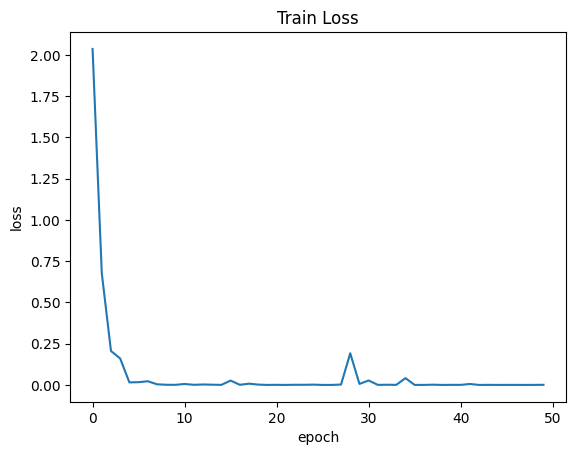

```python
plt.plot (train_loss)
plt.title ("Train Loss")
plt.xlabel ("epoch")
plt.ylabel ("loss")
plt.show ()
```

Here, I plot accuracy for each epoch. For first epochs accuracy is lower. As we are training more epochs accuracy is converging to one.

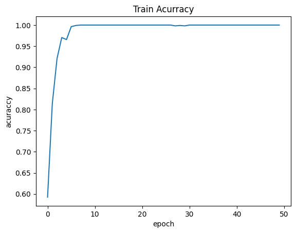

```python
plt.plot (train_acc)
plt.title ("Train Acurracy")
plt.xlabel ("epoch")
plt.ylabel ("acuraccy")
plt.show ()
```

#### Testing

Testing is like training but we don't compute gradients because we don't want to update parameters. The output for each data is probability for each class, so we should find the maximum probability to assign data to class.

```python
correct = 0
total = 0

r = []
p = []

with torch.no_grad():
    for data in test_dataloader:
        images, labels = data

        images = images.to (torch.float)
        images = images.to (device)
        labels = labels.to (device)

        outputs = model (images)

        _, predicted = torch.max(outputs.data, 1)

        total += labels.size(0)
        correct += (predicted == labels).sum().item()

        r = r + labels.tolist ()
        p = p + predicted.tolist ()

print("Accuracy:", 100 * correct / total)
```

```
Accuracy: 81.36882129277566
```

#### Conclusion

Now, I plot confusion matrix. As it shows the model predicts meningioma well. The reason can be that this class is more unique than others. The model doesn't predict glioma well.

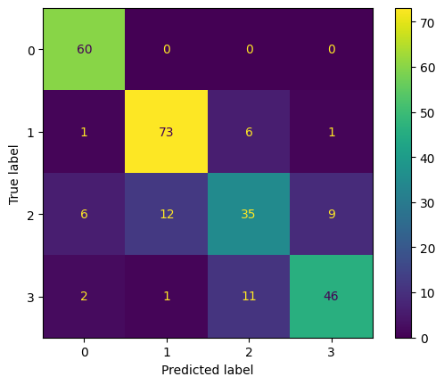

```python
confusion_matrix = metrics.confusion_matrix(r, p)

cm_display = metrics.ConfusionMatrixDisplay(confusion_matrix = confusion_matrix, display_labels = [0, 1, 2, 3])

cm_display.plot()
plt.show()
```

```python
print (classification_report (r, p, labels = [0, 1, 2, 3]))
```

```
              precision    recall  f1-score   support

           0       0.87      1.00      0.93        60
           1       0.85      0.90      0.87        81
           2       0.67      0.56      0.61        62
           3       0.82      0.77      0.79        60

    accuracy                           0.81       263
   macro avg       0.80      0.81      0.80       263
weighted avg       0.81      0.81      0.81       263
```

Precision: It measures the accuracy of the positive predictions. </br> Recall: It calculates how many of the actual positive instances were correctly predicted by the model. </br> F1-Score: It is the harmonic mean of precision and recall. </br> Support: It indicates the number of actual occurrences of each class in the dataset. </br> Marco Average: It calculates the unweighted mean of precision, recall, and F1-score across all classes. </br> Weighted Average: It calculates the weighted average of precision, recall, and F1-score, weighted by the number of instances for each class.

#### Questions

Normalizing images means scaling pixel values to specific range. </br> Advantages: Reduced scaled variance - Increased noise resistance - Faster Training </br> Disadvantages: Information loss - Implementation complexity

I devided dataset to train and test with ratio 0.8 for train dataset because it is a traditional ratio and reaching good accuracy.

L1Loss: L1 Loss, also known as Mean Absolute Error (MAE), is a regression loss function used to measure the average magnitude of errors between predicted and actual values. </br> MSELoss: MSELoss stands for Mean Squared Error Loss, and it's used regression loss function in machine learning. This loss function calculates the average of the squared differences between predicted and actual values. </br> CrossEntropyLoss: It is a commonly used loss function, particularly in multi-class classification problems. It calculates the loss between predicted class probabilities and the actual class labels. </br> CTCLoss: CTC (Connectionist Temporal Classification) Loss is a loss function primarily used in sequence-based tasks, such as automatic speech recognition (ASR) or handwriting recognition, where the alignment between inputs and targets is not explicitly known. </br> </br> I used CrossEntropyLoss function because we have multi-class classification and It is more popular for this. </br> CrossEntropyLoss applies Softmax

Adam optimizer: Adam (Adaptive Moment Estimation) is an optimization algorithm commonly used in training neural networks. It's an extension of stochastic gradient descent (SGD) that combines the ideas of adaptive learning rates and momentum. Adam adapts the learning rates for each parameter in the network by calculating individual adaptive learning rates. It maintains separate learning rates for each parameter and updates them based on the history of gradients for that parameter. </br> The main differences between Adam and SGD are in their optimization strategies and the way they update model parameters during training. SGD uses a fixed learning rate throughout the training process for updating all model parameters. Adam adapts the learning rates for each parameter individually based on the past gradients for those parameters. SGD does not maintain adaptive estimates of first and second-order moments of the gradients. Adam computes adaptive estimates of both the first and second moments of the gradients.

Datalaoder: It is used for loading, transforming data into tensors, and dividing it into batches for training neural networks. This class offers functionalities such as random batch selection, batch size configuration, data augmentation, and more. </br> Batch Size: It refers to number of data samples that are given to the model. Increasing the batch size can improve training speed and efficiency as computations are done in parallel for each batch during an iteration, but It needs more memory and some hardware resources.

Dropout: It works by randomly deactivating a certain percentage of neurons with probability p in a layer during each training iteration. </br> Batch Normalization: It is a technique used in neural networks to improve training stability, accelerate convergence, and reduce the impact of internal covariate shift. The core idea behind batch normalization is to normalize the input of a layer by subtracting the batch mean and dividing by the batch standard deviation. This process is applied independently to each feature or channel in the input. </br> Without dropuot and bach normalization the accuracy is about 75%.

Relu is zeroing out negetive values. It helps in making the model sparse and computationally efficient by removing unnecessary negative activations. ReLU has a simple derivative (1 for positive inputs, 0 for negative inputs), which helps in easier gradient propagation during backpropagation compared to other activation functions

I used SGD optimizer because I reached more accuracy with SGD than adam.